# Step 4: Analysing BIO-WELL scores

# Introduction

After your BIO-WELL survey URL has been shared to participants and their responses have been remotely stored to your Dropbox App’s folder, it is time to move to the analysis stage.

In this vignette, we will be using the `BIOWELL` package functions `download_data()`, `evaluate_survey()` and `explore_data()` to download the survey response data, evaluate your survey and explore patterns in BIO-WELL scores.

# Step 1: Download survey response data

Participant responses have been saved as individual `csv` files within your designated Dropbox App’s folder.

The `BIOWELL` package function `download_data()` collates all survey responses and returns a single data frame for analysis.

```r
path_to_folder <- tempdir() # Replace with path to your local folder containing app.R
dir.create(paste0(path_to_folder,"/",appName))

Dropbox_App_folder_name <- "your-Dropbox-folder-name" # The same one used in build_survey()

survey_data <- download_data(Dropbox_App_folder = Dropbox_App_folder_name,
                             BW_app_path = path_to_folder)
```

For your own modelling and analysis purposes, you may want to save the downloaded data to a local directory.

Run the code below to save the data frame as a csv file. You can change the path and file name to save to a local directory of your choice.

```r
local_directory <- tempdir() # Here we save to your temporary directory, but this can be a path to any local directory

file_name <- "my_survey_data" # Here you can change the filename to anything you want.

write.csv(survey_data, file = paste0(file_name, ".csv"))
```

# Step 2: Evaluate survey

When analysing survey response data, it is important to evaluate the reliability of your survey.

The function `evaluate_survey()` offers multiple methods to evaluate the reliability of surveys.

1. **Cronbach’s alpha**

The computed Cronbach’s Alpha statistic measures the reliability, or internal consistency, of the five wellbeing sliders. This can be calculated for each biodiversity statement and will help understand the strength or consistency with which the sliders collectively measure a biopsychosocial-spiritual model of wellbeing. The resulting alpha statistic can be compared to those obtained in the original Irvine et al. (2023) article. This is calculated using `cronbach.alpha()` function from the `ltm` R package (Rizopoulos et al., 2007).

2. **Item-total correlation**

The computed item-total statistic for each BIO-WELL question within your survey (Cronbach et al., 1951). This assesses how strongly scores on one wellbeing slider are related to scores on all the other wellbeing sliders. It also contributes to understanding the reliability of the wellbeing sliders as a measure of a biopsychosocial-spiritual model of wellbeing. This is calculated using the `item.total()` function from the `multilevel` [R package](https://CRAN.R-project.org/package=multilevel).

Cronbach, L. J. (1951) Coefficient alpha and the internal structure of tests. Psychometrika, 16, 297–334.

```r
library(BIOWELL)
data("sample_BW_data")
results <- evaluate_survey(sample_BW_data)
results[[2]]
```

```
#>
#> Cronbach's alpha for the 't(raw)' data-set
#>
#> Items: 17
#> Sample units: 300
#> alpha: 0.981
```

```r
results[[3]]
```

```
#>    Variable Item.Total Alpha.Without   N
#> 1         1  0.4145226     0.9832425 300
#> 2         2  0.8497754     0.9794168 300
#> 3         3  0.8713703     0.9791599 300
#> 4         4  0.8563044     0.9793461 300
#> 5         5  0.7981712     0.9800245 300
#> 6         6  0.9063851     0.9787370 300
#> 7         7  0.9255636     0.9784992 300
#> 8         8  0.8947779     0.9788913 300
#> 9         9  0.9182825     0.9785958 300
#> 10       10  0.9109638     0.9786982 300
#> 11       11  0.9286393     0.9784722 300
#> 12       12  0.8356632     0.9795869 300
#> 13       13  0.8758599     0.9791066 300
#> 14       14  0.9013126     0.9787957 300
#> 15       15  0.8991299     0.9788247 300
#> 16       16  0.8512047     0.9794184 300
#> 17       17  0.8357615     0.9796053 300
```

# Step 3: Explore survey responses

To facilitate preliminary analyses of survey response data, the `BIOWELL` package includes the function `explore_data()`.

The arguments of the function are:

- `data` - The download survey response data frame (from Step 1!).
- `var_name` - A character string, text for the y-axis of the returned box plot.
- `plot` - A logical, whether you want the box plots to be displayed in the R plot window.
- `column_name` - An optional argument, the name of a column within data to split BIO-WELL scores by in the returned box plot.
- `biowell_scale` - An optional argument, the name of one wellbeing domain with the BIO-WELL scale. If specified, plotted BIO-WELL scores only incorporate the slider input for this domain. One of; `physical`, `emotional`, `cognitive`, `social` and `spiritual`.
- `score` - An optional argument, indicating whether to plot the raw BIO-WELL scores or inverted BIO-WELL scores. One of; `inverted` or `raw`.

By default, the typical, inverted BIO-well score is plotted. This is calculated by taking the average score from across five wellbeing domains (physical, emotional, cognitive, social and spiritual). When `inverted`, the BIO-WELL score can be interpreted as 0-49, a negative wellbeing response to biodiversity, 50, a neutral wellbeing responses and 51-100 representing a positive wellbeing response to biodiversity. The `raw` BIO-WELL scores represents the opposite of this with 0-49, a positive wellbeing response to biodiversity, 50, a neutral wellbeing responses and 51-100 representing a negative wellbeing response.

1. **Default**

If you only provide `explore_data()` with the participant survey response data frame, by default, the function will collate the BIO-WELL scores for each participant by setting and question. The function returns the processed data frame and generates a box plot for each setting to display the BIO-WELL scores for each question within that setting.

**Note: By default this function plots the inverted BIO-WELL scores.**

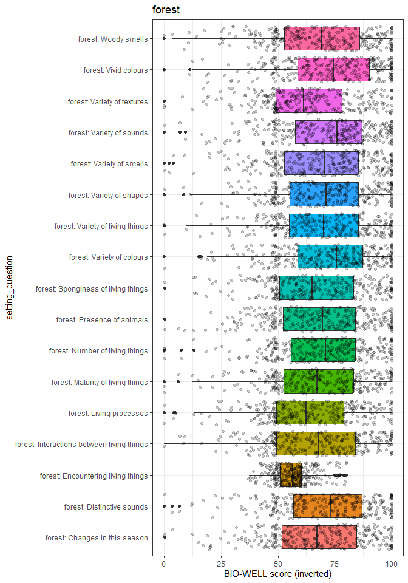

```r
results <- explore_data(data = sample_BW_data,
                        plot = FALSE)
results[[1]][1]
```

However, the argument `score` enables you to plot the raw BIO-WELL scores if desired.

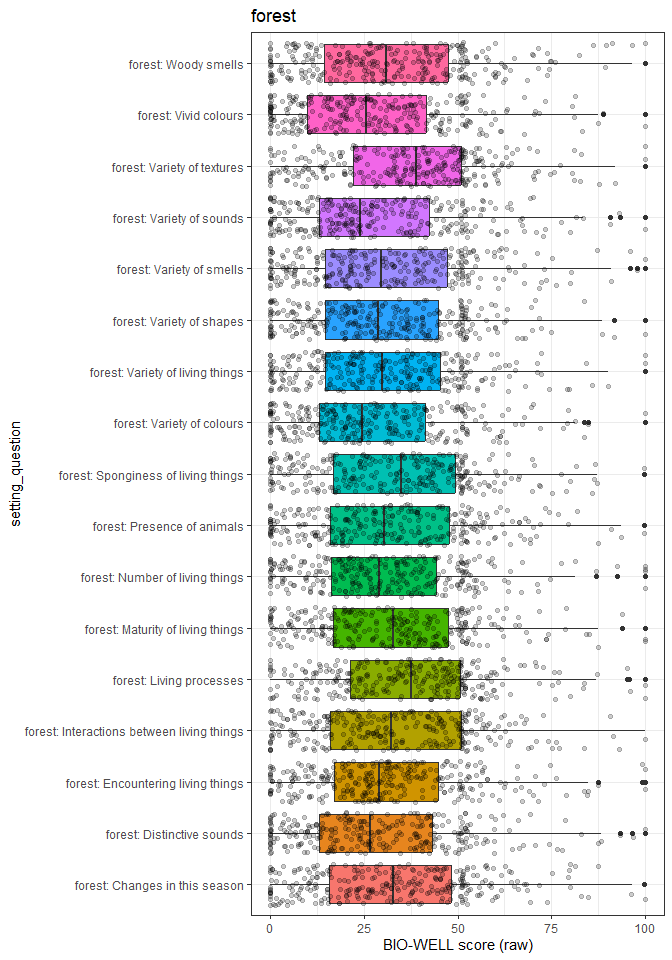

```r
results <- explore_data(data = sample_BW_data,
                        plot = FALSE,
                        score = "raw")
results[[1]][1]
```

Using the argument `biowell_scale`, you could alter the default to plot the BIO-WELL score calculated from only one well-being domain.

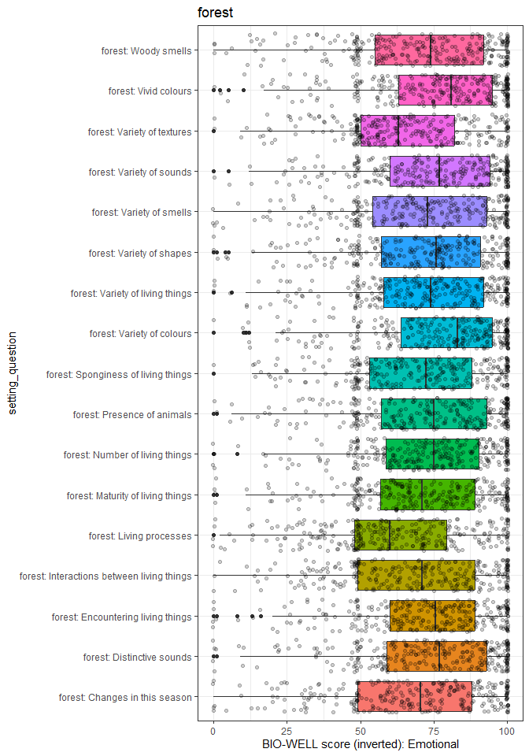

```r
results <- explore_data(data = sample_BW_data,
                        biowell_scale = "emotional",
                        plot = FALSE)
results[[1]][1]
```

2. **Column**

The survey response data frame contains multiple columns including for responses to any start or end questions.

Using the `column_name` argument in `explore_data()` you can specify a column that contains categorical data to split participant BIO-WELL scores by.

For example, the below code will generate a box plot comparing BIO-WELL scores between each age category of participants.

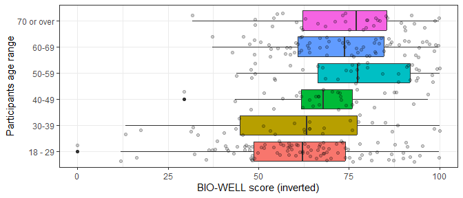

```r
results <- explore_data(data = sample_BW_data,
                        column_name = "Age",
                        var_name = "Participants age range",
                        plot = TRUE)
```

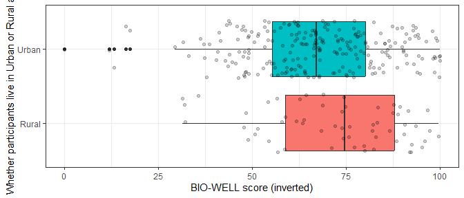

```r
results <- explore_data(data = sample_BW_data,
                        column_name = "Urbanicity",
                        var_name = "Whether participants live in Urban or Rural areas",
                        plot = TRUE)
```

Using the argument `biowell_scale`, you could further alter the `column_name` plot to plot the BIO-WELL score calculated from only one wellbeing domain.

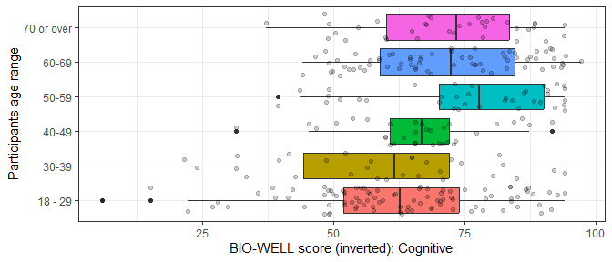

```r
results <- explore_data(data = sample_BW_data,
                        column_name = "Age",
                        var_name = "Participants age range",
                        biowell_scale = "cognitive",
                        plot = TRUE)
```

# Further analyses

We hope the functions covered in this Vignette facilitate preliminary analysis of BIO-WELL scores from your `BIOWELL` package surveys.

This concludes our vignettes for the `BIOWELL` package. Please visit the package’s [GitHub page](https://github.com/r-a-dobson/BIOWELL) to report any bugs or to ask questions on how to use the package.